# Music Album Sales Prediction (A case of linear regression)

Mithun Radhakrishnan

13 April 2018

# **Background**

*Imagine that you worked for a Musice Records company and that your boss is interested in predicting album sales from Adverting. Some requisite historical data is provided for your use.*

**Lets read the historical data**

```r
albumsales1<- read.csv("AlbumSales1.csv",header = TRUE)
```

**Some Summaries**

```r
dim(albumsales1)
```

```
## [1] 200   2
```

```r
summary(albumsales1)
```

```
##     adverts             sales
##  Min.   :   9.104   Min.   : 10.0
##  1st Qu.: 215.918   1st Qu.:137.5
##  Median : 531.916   Median :200.0
##  Mean   : 614.412   Mean   :193.2
##  3rd Qu.: 911.226   3rd Qu.:250.0
##  Max.   :2271.860   Max.   :360.0
```

```r
head(albumsales1,10)
```

```
##     adverts sales
## 1    10.256   330
## 2   985.685   120
## 3  1445.563   360
## 4  1188.193   270
## 5   574.513   220
## 6   568.954   170
## 7   471.814    70
## 8   537.352   210
## 9   514.068   200
## 10  174.093   300
```

- The data consists of 2 variables i.e. 1) Adverts and 2) Sales.
- Both adverts and sales are to be expressed in 1,000’s.
- There are 200 hundred observations of each.
- Data is pristine, with no missing values.

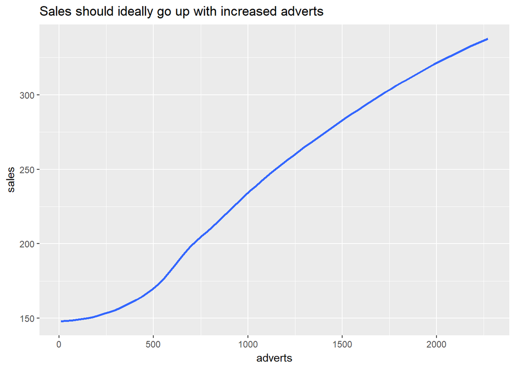

```r
ggplot(albumsales1,aes(adverts,sales))+
  geom_smooth(se=FALSE)+
  labs(
    title= paste("Sales should ideally go up with increased adverts")
  )
```

## ** Lets build a Single variable linear model**

*Linear Regression is called by lm() function. This function takes the general form of*

**model<- lm(outcome ~ predictor(s), data = dataframe, na.action = an na action)**

```r
model1<- lm(albumsales1$sales~albumsales1$adverts)
```

```r
summary(model1)
```

```
##
## Call:
## lm(formula = albumsales1$sales ~ albumsales1$adverts)
##
## Residuals:
##      Min       1Q   Median       3Q      Max
## -152.949  -43.796   -0.393   37.040  211.866
##
## Coefficients:
##                      Estimate Std. Error t value Pr(>|t|)
## (Intercept)         1.341e+02  7.537e+00  17.799   <2e-16 ***
## albumsales1$adverts 9.612e-02  9.632e-03   9.979   <2e-16 ***
## ---
## Signif. codes:  0 '***' 0.001 '**' 0.01 '*' 0.05 '.' 0.1 ' ' 1
##
## Residual standard error: 65.99 on 198 degrees of freedom
## Multiple R-squared:  0.3346, Adjusted R-squared:  0.3313
## F-statistic: 99.59 on 1 and 198 DF,  p-value: < 2.2e-16
```

**Interpretation**

The Multiple R-squared is a measure of overll fit of the model.The logic behind R^2 is that in absence of a predictor variable (here adverts), the best model to base prediction would be the mean of sales. R-squared measures how much of this total error variation is explained by the new regression model.

Here in this model R-squared value stands at 0.33.

There might be many factors that can explain this variation, but this model which includes only advertising expenditure can explain approxmately 33% or it. What it also means that 67% of the variation in album sales cannot be explained by advertising alone.

We also see an F ratio of 99.59 with a p-value less than 0.1% it mean that the null hypthesis about the regression parameters b1=0 does not hold ground. The model predicts the album sales signigicantly better than the mean value of album sales.

**Lets look at the coefficients**

```r
coefficients(model1)
```

```
##         (Intercept) albumsales1$adverts
##        134.13993781          0.09612449
```

```r
confint(model1)
```

```
##                            2.5 %      97.5 %
## (Intercept)         119.27768082 149.0021948
## albumsales1$adverts   0.07712929   0.1151197
```

b0 is the y intercept, here it is 134.1 and this is interpreted as when no money is spent on advertising (when x = 0) the model predicts that 134100 albums wil be sold.

b1 can be seen from the row labeled adverts and this value represents the slope or gradient of the regression line. Here in this case, it is 0.096. This should be understood as the change in outcome associated with a unit change in predictor variable. Again here the predictor variable is adverts and the unit is in 1000’s so a 1000 increase in adverts $1000*0.096$ chnage in the number of album sales.

The model looks some thing like this:

** albumsales = 134.14 + (0.096 Adverts budget)**

*This was a case of single continous varible predicting another, meaning Advert budget used to predict album sales.

## **Now let’s build a Multiple variable linear regression model**

*Some changes in the background, the music records company executive wants you to incorporate other variables as well in the model for prediction of sales.*

**Let’s read the data with new variables**

```r
albumsales2<- read.csv("AlbumSales2.csv", header = TRUE)
```

**Some Summaries**

```r
dim(albumsales2)
```

```
## [1] 200   4
```

```r
head(albumsales2)
```

```
##    adverts sales airplay attract
## 1   10.256   330      43      10
## 2  985.685   120      28       7
## 3 1445.563   360      35       7
## 4 1188.193   270      33       7
## 5  574.513   220      44       5
## 6  568.954   170      19       5
```

```r
summary(albumsales2)
```

```
##     adverts             sales          airplay         attract
##  Min.   :   9.104   Min.   : 10.0   Min.   : 0.00   Min.   : 1.00
##  1st Qu.: 215.918   1st Qu.:137.5   1st Qu.:19.75   1st Qu.: 6.00
##  Median : 531.916   Median :200.0   Median :28.00   Median : 7.00
##  Mean   : 614.412   Mean   :193.2   Mean   :27.50   Mean   : 6.77
##  3rd Qu.: 911.226   3rd Qu.:250.0   3rd Qu.:36.00   3rd Qu.: 8.00
##  Max.   :2271.860   Max.   :360.0   Max.   :63.00   Max.   :10.00
```

**Some Observation Points**

- There are 2 new variables:
- 1. airplay- the number of times songs from album are played in radio
- 2. attract - the attactiveness of the band on a scale of 0 to 10.

*Let’s make some graphs*

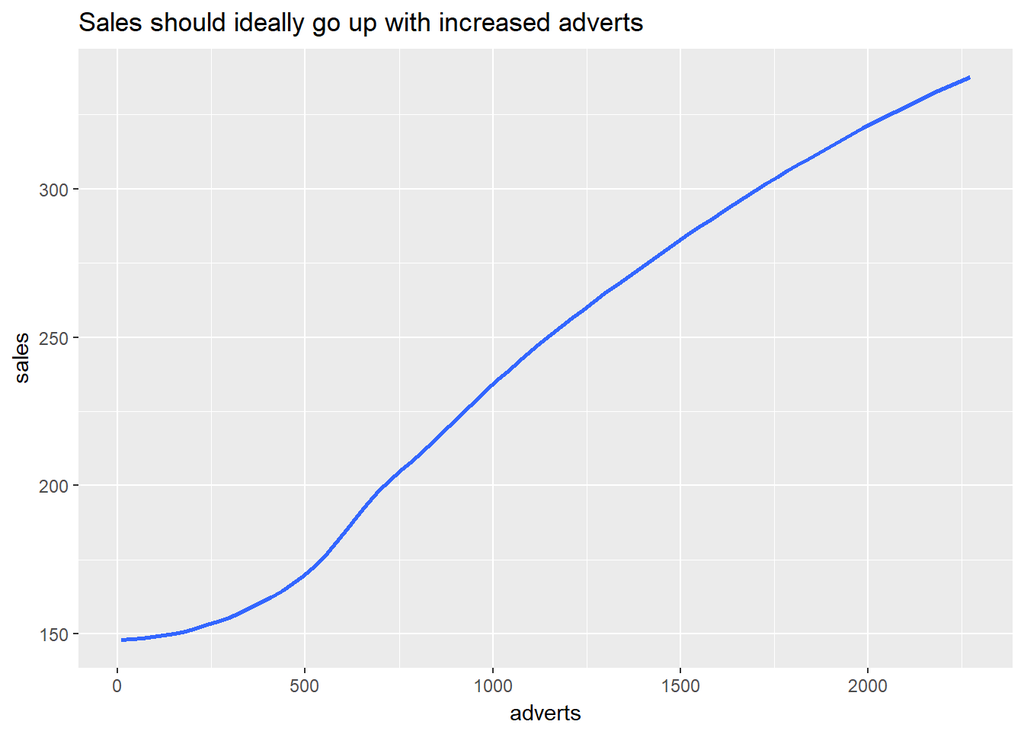

```r
par(mfrow = c(1,3))
ggplot(albumsales2,aes(adverts,sales))+
  geom_smooth(se=FALSE)+
  labs(
    title= paste("Sales should ideally go up with increased adverts")
  )
```

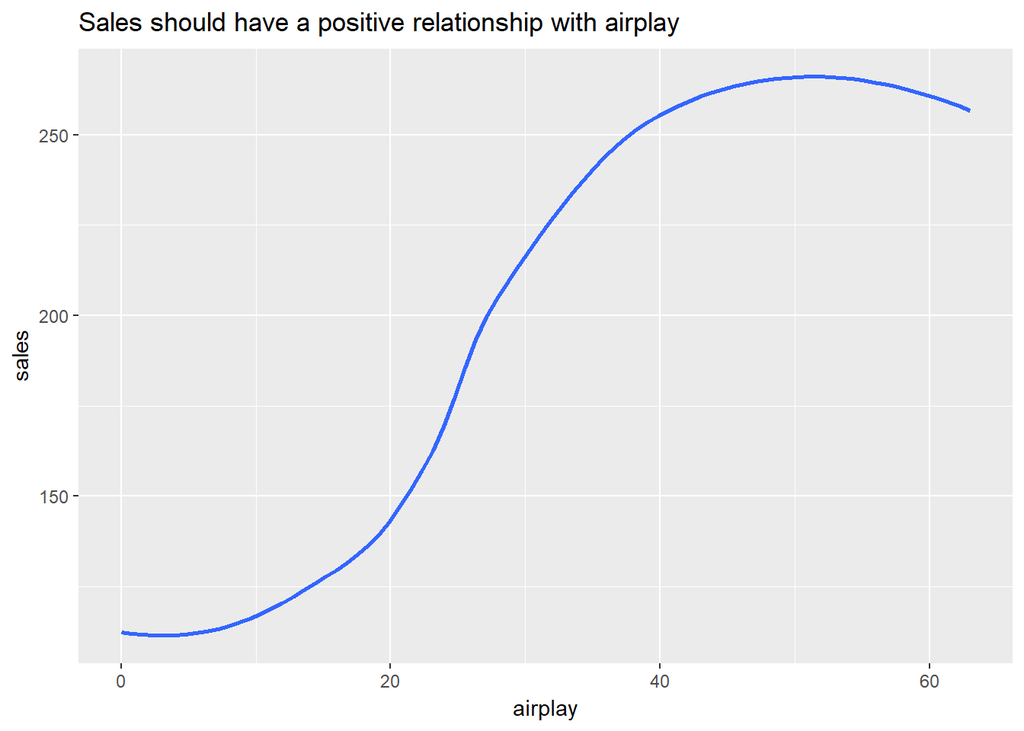

```r
ggplot(albumsales2, aes(airplay,sales))+
  geom_smooth(se=FALSE)+
  labs(
    title = paste("Sales should have a positive relationship with airplay")
  )
```

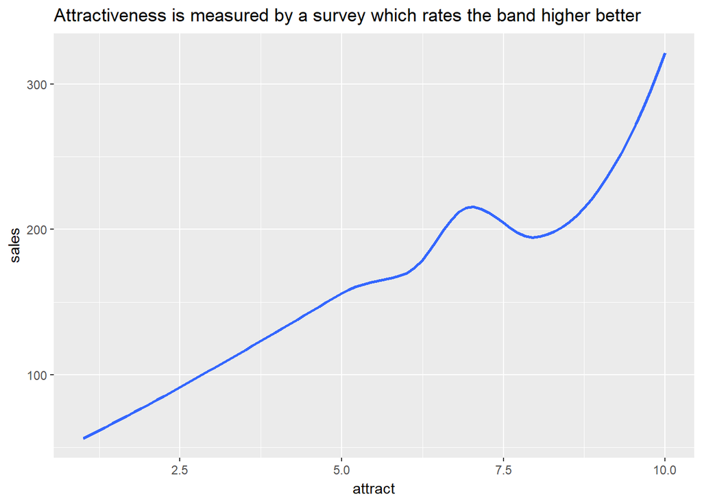

```r
ggplot(albumsales2, aes(attract,sales))+
  geom_smooth(se = FALSE)+
  labs(
    title = paste("Attractiveness is measured by a survey which rates the band higher better")
  )
```

**Building the Multiple Regression Model**

```r
model2<- lm(albumsales2$sales~albumsales2$adverts+albumsales2$airplay+albumsales2$attract)
summary(model2)
```

```
##
## Call:
## lm(formula = albumsales2$sales ~ albumsales2$adverts + albumsales2$airplay +
##     albumsales2$attract)
##
## Residuals:
##      Min       1Q   Median       3Q      Max
## -121.324  -28.336   -0.451   28.967  144.132
##
## Coefficients:
##                       Estimate Std. Error t value Pr(>|t|)
## (Intercept)         -26.612958  17.350001  -1.534    0.127
## albumsales2$adverts   0.084885   0.006923  12.261  < 2e-16 ***
## albumsales2$airplay   3.367425   0.277771  12.123  < 2e-16 ***
## albumsales2$attract  11.086335   2.437849   4.548 9.49e-06 ***
## ---
## Signif. codes:  0 '***' 0.001 '**' 0.01 '*' 0.05 '.' 0.1 ' ' 1
##
## Residual standard error: 47.09 on 196 degrees of freedom
## Multiple R-squared:  0.6647, Adjusted R-squared:  0.6595
## F-statistic: 129.5 on 3 and 196 DF,  p-value: < 2.2e-16
```

**Interpretation**

*R-squared is 0.66, this model explains variation better than model1.

- F-statistic is signicant, so the null of zero beta values gets rejected.

*Lets check the Coefficients of the model

```r
coefficients(model2)
```

```
##         (Intercept) albumsales2$adverts albumsales2$airplay
##        -26.61295836          0.08488483          3.36742517
## albumsales2$attract
##         11.08633520
```

```r
confint(model2)
```

```
##                            2.5 %      97.5 %
## (Intercept)         -60.82960967  7.60369295
## albumsales2$adverts   0.07123166  0.09853799
## albumsales2$airplay   2.81962186  3.91522848
## albumsales2$attract   6.27855218 15.89411823
```

- Adverts b-value is 0.0848 means that if the adverts budget increase by 1 unit (here 1000 dolar), record sales increase by 1000*0.0848 = 84.8 units other things remaining the same.
- Airplay b-value is 3.36 means if airplay incrase by 1 unit there is a 3.36 thousand increase in sales of album.
- Attract b-value 11. 086 means for every one unit increase in the attractiveness of the band we can expect 11.086 thousand increase in album sales.

*The b-values and thier significance are important statistics to look at however standardized values of b are more easy to interpret. (because they are not dependent on the units of measurement of the variables.)*

** To obtain standardized estimates of beta use lm.beta() function**

```r
library(QuantPsyc)
lm.beta(model2)
```

```
## albumsales2$adverts albumsales2$airplay albumsales2$attract
##           0.5108462           0.5119881           0.1916834
```

*Interpretation* If adverts increases by one standard deviation (past), the sales increase by 0.51 standard deviation. If airplay increase by one standard deviation the album sales increase by 0.5119 standard deviation and lastly if the attractive ness of band increases by one standard deviation the sales incease of by 0.19 standard deviation of sales.

** Comparing Models**

Since the models are coming from 2 different data sets, R wont be able to compare. Lets create one more model which model 1 only but its coming from the second dataframe.

```r
model3<- lm(albumsales2$sales~albumsales2$adverts)
```

** Assessing Model improvement**

*If we have done a heirarchial regression, then you can assess the improverment of the model at each stage of the analysis by looking at the change in R-squared and testing whether this change is signigicant using ANNOVA*

```r
anova(model3,model2)
```

```
## Analysis of Variance Table
##
## Model 1: albumsales2$sales ~ albumsales2$adverts
## Model 2: albumsales2$sales ~ albumsales2$adverts + albumsales2$airplay +
##     albumsales2$attract
##   Res.Df    RSS Df Sum of Sq      F    Pr(>F)
## 1    198 862264
## 2    196 434575  2    427690 96.447 < 2.2e-16 ***
## ---
## Signif. codes:  0 '***' 0.001 '**' 0.01 '*' 0.05 '.' 0.1 ' ' 1
```

- So we have an F ratio of 96.44 with a very low p-value which indicate that model 2 is a significantly improved fit compared to model 3.